# Comparación de concentraciones de estroncio en cuerpos de agua

Andrea Michelle Luna Vasconcelos – 1950889

22/09/2025

## Descripción de los datos

```r
estroncio <- read.csv("C:/Repositorio GitHub/Posgrado_Estadistica_2025/Tarea 22_09/Estroncio mg_ml.csv")
library(knitr)
kable(head(estroncio), caption = "Concentración de estroncio (mg/ml) en cinco cuerpos de agua (n = 6)")
```

Concentración de estroncio (mg/ml) en cinco cuerpos de agua (n = 6)

| Muestra | Grayson.s.Pond | Beaver.Lake | Angler.s.Cove | Appletree.Lake | Rock.River |
| --- | --- | --- | --- | --- | --- |
| 1 | 28.2 | 39.6 | 46.3 | 41.0 | 56.3 |
| 2 | 33.2 | 40.8 | 42.1 | 44.1 | 54.1 |
| 3 | 36.4 | 37.9 | 43.5 | 46.4 | 59.4 |
| 4 | 34.6 | 37.1 | 48.8 | 40.2 | 62.7 |
| 5 | 29.1 | 43.6 | 43.7 | 38.6 | 60.0 |
| 6 | 31.0 | 42.4 | 40.1 | 36.3 | 57.3 |

```r
library(tidyverse)

estroncio_long <- estroncio %>%
  pivot_longer(cols = -Muestra,
               names_to = "Cuerpo_agua",
               values_to = "Concentracion")

estroncio_long$Cuerpo_agua <- as.factor(estroncio_long$Cuerpo_agua)

kable(estroncio_long, caption = "Datos reorganizados de concentraciones de estroncio (mg/ml) en cinco cuerpos de agua como factor")
```

Datos reorganizados de concentraciones de estroncio (mg/ml) en cinco cuerpos de agua como factor

| Muestra | Cuerpo_agua | Concentracion |
| --- | --- | --- |
| 1 | Grayson.s.Pond | 28.2 |
| 1 | Beaver.Lake | 39.6 |
| 1 | Angler.s.Cove | 46.3 |
| 1 | Appletree.Lake | 41.0 |
| 1 | Rock.River | 56.3 |
| 2 | Grayson.s.Pond | 33.2 |
| 2 | Beaver.Lake | 40.8 |
| 2 | Angler.s.Cove | 42.1 |
| 2 | Appletree.Lake | 44.1 |
| 2 | Rock.River | 54.1 |
| 3 | Grayson.s.Pond | 36.4 |
| 3 | Beaver.Lake | 37.9 |
| 3 | Angler.s.Cove | 43.5 |
| 3 | Appletree.Lake | 46.4 |
| 3 | Rock.River | 59.4 |
| 4 | Grayson.s.Pond | 34.6 |
| 4 | Beaver.Lake | 37.1 |
| 4 | Angler.s.Cove | 48.8 |
| 4 | Appletree.Lake | 40.2 |
| 4 | Rock.River | 62.7 |
| 5 | Grayson.s.Pond | 29.1 |
| 5 | Beaver.Lake | 43.6 |
| 5 | Angler.s.Cove | 43.7 |
| 5 | Appletree.Lake | 38.6 |
| 5 | Rock.River | 60.0 |
| 6 | Grayson.s.Pond | 31.0 |
| 6 | Beaver.Lake | 42.4 |
| 6 | Angler.s.Cove | 40.1 |
| 6 | Appletree.Lake | 36.3 |
| 6 | Rock.River | 57.3 |

```r
medias <- tapply(estroncio_long$Concentracion, estroncio_long$Cuerpo_agua, mean)
kable(medias, caption = "Medias de concentración de estroncio (mg/ml) por cuerpo de agua",
      col.names = c("Cuerpo de agua", "Media (mg/ml)"))
```

Medias de concentración de estroncio (mg/ml) por cuerpo de agua

| Cuerpo de agua | Media (mg/ml) |
| --- | --- |
| Angler.s.Cove | 44.08333 |
| Appletree.Lake | 41.10000 |
| Beaver.Lake | 40.23333 |
| Grayson.s.Pond | 32.08333 |
| Rock.River | 58.30000 |

## Hipótesis del ANOVA

- **H0:** La media de concentración de estroncio en todos los cuerpos de agua es igual.
- **H1:** Al menos una media de concentración de estroncio es diferente.

## Cálculo del ANOVA

```r
bartlett.test(estroncio_long$Concentracion ~ estroncio_long$Cuerpo_agua)
```

```
##
##  Bartlett test of homogeneity of variances
##
## data:  estroncio_long$Concentracion by estroncio_long$Cuerpo_agua
## Bartlett's K-squared = 0.63895, df = 4, p-value = 0.9586
```

```r
estroncio_long.aov <- aov(estroncio_long$Concentracion ~ estroncio_long$Cuerpo_agua)
summary(estroncio_long.aov)
```

```
##                            Df Sum Sq Mean Sq F value   Pr(>F)
## estroncio_long$Cuerpo_agua  4 2193.4   548.4   56.16 3.95e-12 ***
## Residuals                  25  244.1     9.8
## ---
## Signif. codes:  0 '***' 0.001 '**' 0.01 '*' 0.05 '.' 0.1 ' ' 1
```

```r
library(broom)
anova <- tidy(estroncio_long.aov)
kable(anova, caption = "Resultados de análisis de varianza (ANOVA de una vía)")
```

Resultados de análisis de varianza (ANOVA de una vía)

| term | df | sumsq | meansq | statistic | p.value |
| --- | --- | --- | --- | --- | --- |
| estroncio_long$Cuerpo_agua | 4 | 2193.442 | 548.3605 | 56.15456 | 0 |
| Residuals | 25 | 244.130 | 9.7652 | NA | NA |

## Gráfica de distribución

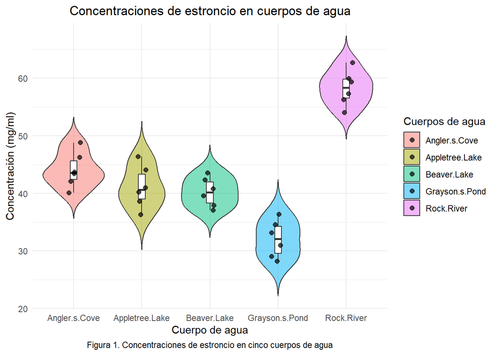

```r
library(ggplot2)

ggplot(estroncio_long, aes(x = Cuerpo_agua, y = Concentracion, fill = Cuerpo_agua)) +
  geom_violin(trim = FALSE, alpha = 0.5) +
  geom_boxplot(width = 0.1, fill = "white", outlier.shape = NA) +
  geom_jitter(width = 0.1, size = 2, alpha = 0.7) +
  labs(
    title = "Concentraciones de estroncio en cuerpos de agua",
    x = "Cuerpo de agua",
    y = "Concentración (mg/ml)",
    fill = "Cuerpos de agua",
    caption = "Figura 1. Concentraciones de estroncio en cinco cuerpos de agua"
  ) +
  theme_minimal() +
  theme(plot.title = element_text(hjust = 0.5),
        plot.caption = element_text(hjust = 0.5))
```

## Prueba LSD

```r
LSD <- sqrt((2*9.8)/6) * qt(0.975, 25)
LSD
```

```
## [1] 3.722394
```

## Comparación por pares con LSD:

```r
resultados <- data.frame(
  Comparacion = c(
    "Grayson’s Pond vs Beaver Lake",
    "Grayson’s Pond vs Angler’s Cove",
    "Grayson’s Pond vs Appletree Lake",
    "Grayson’s Pond vs Rock River",
    "Beaver Lake vs Angler’s Cove",
    "Beaver Lake vs Appletree Lake",
    "Beaver Lake vs Rock River",
    "Angler’s Cove vs Appletree Lake",
    "Angler’s Cove vs Rock River",
    "Appletree Lake vs Rock River"
  ),
  Diferencia = c(-8.15, -12.00, -9.017, -26.217, -3.85, -0.867, -18.067, 2.983, -14.217, -17.2),
  Significancia = c("Significativa", "Significativa", "Significativa", "Significativa",
                    "Significativa", "No significativa", "Significativa",
                    "No significativa", "Significativa", "Significativa")
)
kable(resultados, caption = "Resultados LSD de comparación entre pares de medias",
      col.names = c("Pares de medias", "Diferencia (mg/ml)", "Resultado LSD"))
```

Resultados LSD de comparación entre pares de medias

| Pares de medias | Diferencia (mg/ml) | Resultado LSD |
| --- | --- | --- |
| Grayson’s Pond vs Beaver Lake | -8.150 | Significativa |
| Grayson’s Pond vs Angler’s Cove | -12.000 | Significativa |
| Grayson’s Pond vs Appletree Lake | -9.017 | Significativa |
| Grayson’s Pond vs Rock River | -26.217 | Significativa |
| Beaver Lake vs Angler’s Cove | -3.850 | Significativa |
| Beaver Lake vs Appletree Lake | -0.867 | No significativa |
| Beaver Lake vs Rock River | -18.067 | Significativa |
| Angler’s Cove vs Appletree Lake | 2.983 | No significativa |
| Angler’s Cove vs Rock River | -14.217 | Significativa |
| Appletree Lake vs Rock River | -17.200 | Significativa |

## Prueba Tukey HSD

```r
PTukey <- sqrt(9.8/6) * qtukey(0.95, nmeans = 5, df = 25)
PTukey
```

```
## [1] 5.308078
```

```r
TukeyHSD(estroncio_long.aov)
```

```
##   Tukey multiple comparisons of means
##     95% family-wise confidence level
##
## Fit: aov(formula = estroncio_long$Concentracion ~ estroncio_long$Cuerpo_agua)
##
## $`estroncio_long$Cuerpo_agua`
##                                      diff        lwr       upr     p adj
## Appletree.Lake-Angler.s.Cove   -2.9833333  -8.281979  2.315312 0.4791100
## Beaver.Lake-Angler.s.Cove      -3.8500000  -9.148645  1.448645 0.2376217
## Grayson.s.Pond-Angler.s.Cove  -12.0000000 -17.298645 -6.701355 0.0000053
## Rock.River-Angler.s.Cove       14.2166667   8.918021 19.515312 0.0000003
## Beaver.Lake-Appletree.Lake     -0.8666667  -6.165312  4.431979 0.9884803
## Grayson.s.Pond-Appletree.Lake  -9.0166667 -14.315312 -3.718021 0.0003339
## Rock.River-Appletree.Lake      17.2000000  11.901355 22.498645 0.0000000
## Grayson.s.Pond-Beaver.Lake     -8.1500000 -13.448645 -2.851355 0.0011293
## Rock.River-Beaver.Lake         18.0666667  12.768021 23.365312 0.0000000
## Rock.River-Grayson.s.Pond      26.2166667  20.918021 31.515312 0.0000000
```

## Tabla de comparaciones con Tukey:

```r
resultadosHSD <- data.frame(
  Comparacion = c(
    "Grayson’s Pond vs Beaver Lake",
    "Grayson’s Pond vs Angler’s Cove",
    "Grayson’s Pond vs Appletree Lake",
    "Grayson’s Pond vs Rock River",
    "Beaver Lake vs Angler’s Cove",
    "Beaver Lake vs Appletree Lake",
    "Beaver Lake vs Rock River",
    "Angler’s Cove vs Appletree Lake",
    "Angler’s Cove vs Rock River",
    "Appletree Lake vs Rock River"
  ),
  Diferencia = c(-8.15, -12.00, -9.017, -26.217, -3.85, -0.867, -18.067, 2.983, -14.217, -17.2),
  Significancia = c("Significativa", "Significativa", "Significativa", "Significativa",
                    "No significativa", "No significativa", "Significativa",
                    "No significativa", "Significativa", "Significativa")
)
kable(resultadosHSD, caption = "Resultados Tukey HSD de comparación entre pares de medias",
      col.names = c("Pares de medias", "Diferencia (mg/ml)", "Resultado Tukey HSD"))
```

Resultados Tukey HSD de comparación entre pares de medias

| Pares de medias | Diferencia (mg/ml) | Resultado Tukey HSD |
| --- | --- | --- |
| Grayson’s Pond vs Beaver Lake | -8.150 | Significativa |
| Grayson’s Pond vs Angler’s Cove | -12.000 | Significativa |
| Grayson’s Pond vs Appletree Lake | -9.017 | Significativa |
| Grayson’s Pond vs Rock River | -26.217 | Significativa |
| Beaver Lake vs Angler’s Cove | -3.850 | No significativa |
| Beaver Lake vs Appletree Lake | -0.867 | No significativa |
| Beaver Lake vs Rock River | -18.067 | Significativa |
| Angler’s Cove vs Appletree Lake | 2.983 | No significativa |
| Angler’s Cove vs Rock River | -14.217 | Significativa |
| Appletree Lake vs Rock River | -17.200 | Significativa |

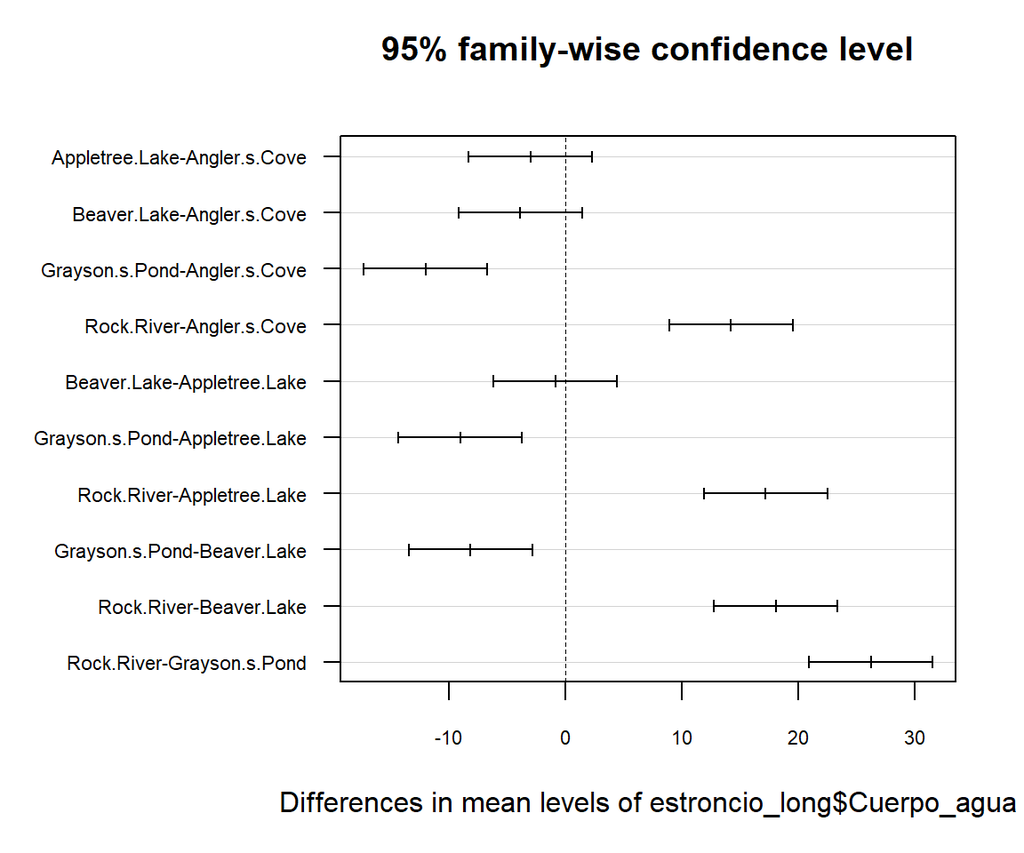

Diferencias de medias en los niveles de estroncio en cuerpos de agua

```r
par(mar = c(5, 10, 4, 2))
plot(TukeyHSD(estroncio_long.aov), las = 1, cex.axis = 0.7)
```

## Comparación LSD vs Tukey HSD

```r
comparaciones <- c(
  "Grayson’s Pond vs Beaver Lake",
  "Grayson’s Pond vs Angler’s Cove",
  "Grayson’s Pond vs Appletree Lake",
  "Grayson’s Pond vs Rock River",
  "Beaver Lake vs Angler’s Cove",
  "Beaver Lake vs Appletree Lake",
  "Beaver Lake vs Rock River",
  "Angler’s Cove vs Appletree Lake",
  "Angler’s Cove vs Rock River",
  "Appletree Lake vs Rock River"
)

diferencias <- c(-8.15, -12.00, -9.017, -26.217, -3.85, -0.867, -18.067, 2.983, -14.217, -17.2)

resultado_LSD <- c("Significativa", "Significativa", "Significativa", "Significativa",
                   "Significativa", "No significativa", "Significativa",
                   "No significativa", "Significativa", "Significativa")

resultado_Tukey <- c("Significativa", "Significativa", "Significativa", "Significativa",
                     "No significativa", "No significativa", "Significativa",
                     "No significativa", "Significativa", "Significativa")

resultadosComparados <- data.frame(
  `Pares de medias` = comparaciones,
  `Diferencia (mg/ml)` = diferencias,
  `Resultado LSD` = resultado_LSD,
  `Resultado Tukey HSD` = resultado_Tukey
)

kable(resultadosComparados,
      caption = "Comparación de resultados LSD vs Tukey HSD entre pares de medias",
      col.names = c("Pares de medias", "Diferencia (mg/ml)", "Resultado LSD", "Resultado Tukey HSD"))
```

Comparación de resultados LSD vs Tukey HSD entre pares de medias

| Pares de medias | Diferencia (mg/ml) | Resultado LSD | Resultado Tukey HSD |
| --- | --- | --- | --- |
| Grayson’s Pond vs Beaver Lake | -8.150 | Significativa | Significativa |
| Grayson’s Pond vs Angler’s Cove | -12.000 | Significativa | Significativa |
| Grayson’s Pond vs Appletree Lake | -9.017 | Significativa | Significativa |
| Grayson’s Pond vs Rock River | -26.217 | Significativa | Significativa |
| Beaver Lake vs Angler’s Cove | -3.850 | Significativa | No significativa |
| Beaver Lake vs Appletree Lake | -0.867 | No significativa | No significativa |
| Beaver Lake vs Rock River | -18.067 | Significativa | Significativa |
| Angler’s Cove vs Appletree Lake | 2.983 | No significativa | No significativa |
| Angler’s Cove vs Rock River | -14.217 | Significativa | Significativa |
| Appletree Lake vs Rock River | -17.200 | Significativa | Significativa |

## Interpretación ambiental

¿Qué sitios no difieren entre sí?

-Según LSD: Beaver Lake vs Appletree Lake y Angler’s Cove vs Appletree Lake. -Según Tukey HSD: los mismos de LSD, más Beaver Lake vs Angler’s Cove.

¿Qué implicaciones podrían tener estas diferencias en la calidad del agua?

-Las diferencias en las concentraciones de estroncio entre cuerpos de agua indican una variabilidad en la calidad. Los sitios con valores más altos podrían estar expuestos a contaminación local o condiciones específicas, lo que representa un riesgo potencial para la fauna y flora local. Asimismo, estas diferencias pueden tener implicaciones en el uso humano del agua (consumo, riego o recreación), por lo que los sitios con mayores concentraciones requieren mayor monitoreo y gestión ambiental.